# Adding a north arrow to a map

There are those who might insist that every map needs a north arrow and a scale bar. I would argue that a north arrow is necessary if it’s useful to the audience. If you are creating a map of South America, and your audience is familiar enough with South American to recognize its shape, you may not need a north arrow.

For other maps, a north arrow is helpful.

# Required packages

These example uses the following packages:

```r
library(tidyverse)
library(sf)
library(ggspatial)
```

# Loading some sample data

I’ll demonstrate with a map of arterial streets in Edmonton, Alberta (data are from Open Street Map via the `osmextract` package).

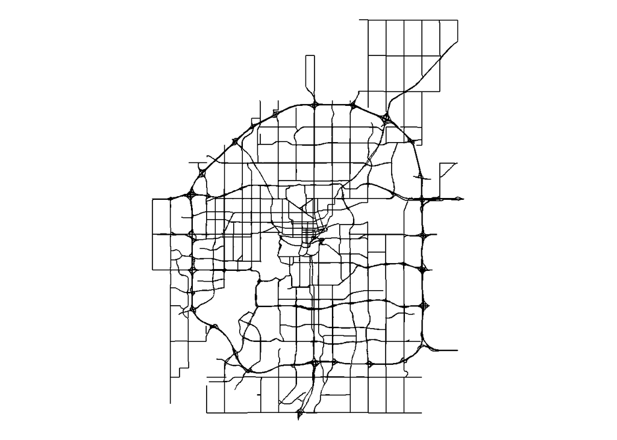

```r
edmonton_map <- ggplot(edmonton) +
  geom_sf() +
  theme_void()

edmonton_map
```

# Add a north arrow

The `ggspatial` package has a useful function called `annotation_north_arrow()` that will add a north arrow to your map.

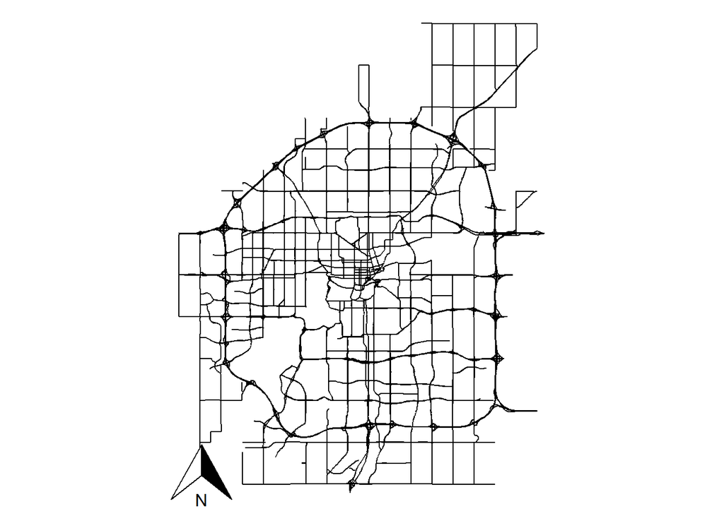

```r
edmonton_map +
  annotation_north_arrow()
```

# Place the north arrow

By default, the north arrow is in the bottom left corner, but you can specify which corner of the map to place it using the `location` argument.

- `tr` means “top right”.
- `tl` means “top left”.
- `br` means “bottom right”.
- `bl` means “bottom left”

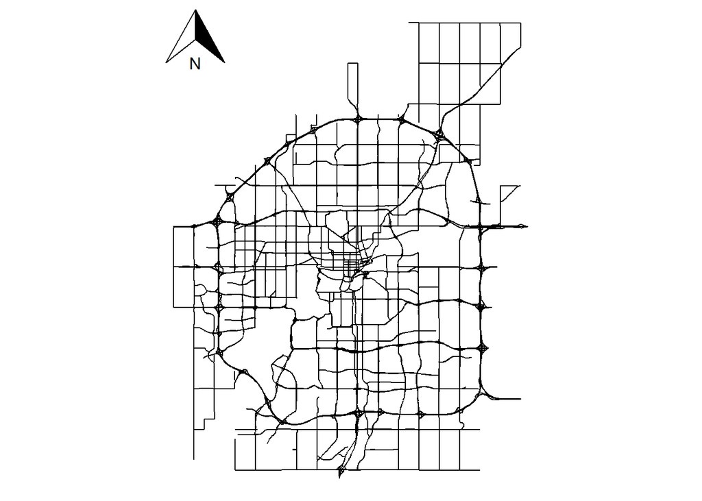

```r
edmonton_map +
  annotation_north_arrow(location = "tl")
```

# Select a north arrow style

You have four different option for north arrow styles:

`north_arrow_orienteering` (this is the default)

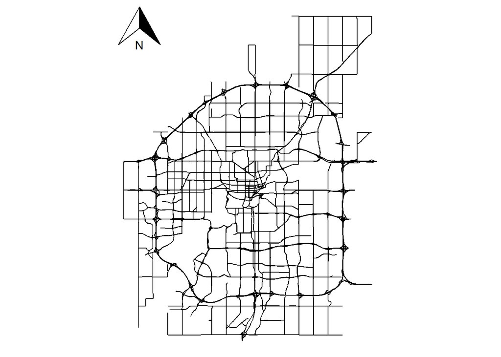

```r
edmonton_map +
  annotation_north_arrow(location = "tl",
                         style = north_arrow_orienteering())
```

`north_arrow_fancy_orienteering`

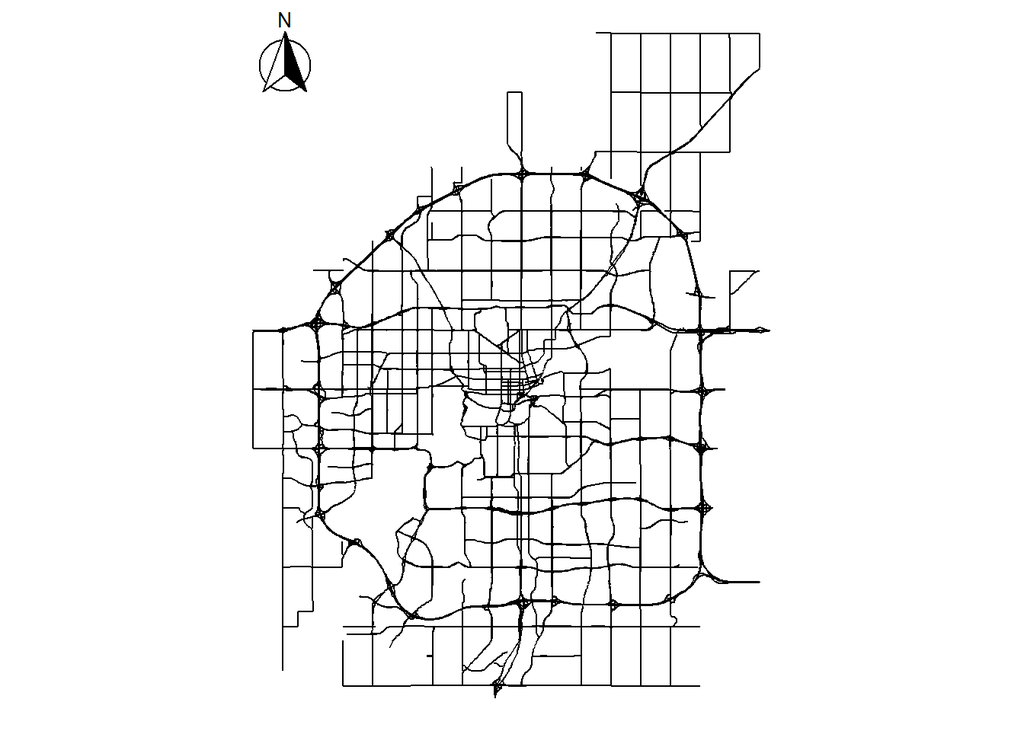

```r
edmonton_map +
  annotation_north_arrow(location = "tl",
                         style = north_arrow_fancy_orienteering())
```

`north_arrow_minimal`

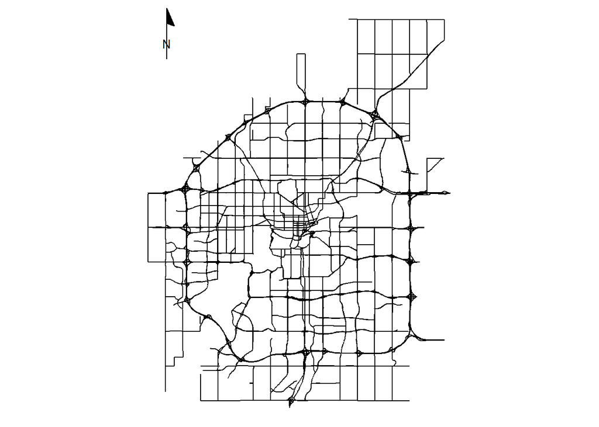

```r
edmonton_map +
  annotation_north_arrow(location = "tl",
                         style = north_arrow_minimal())
```

`north_arrow_nautical`

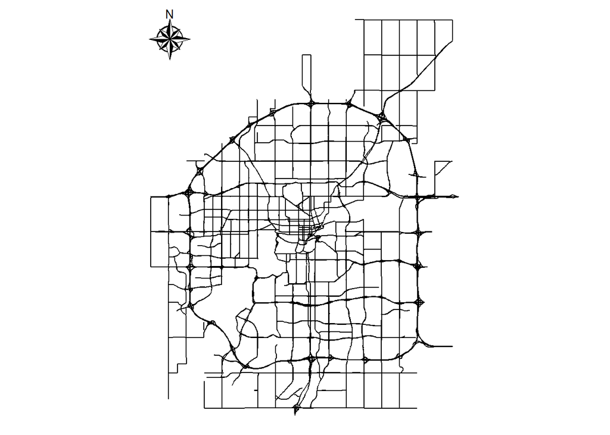

```r
edmonton_map +
  annotation_north_arrow(location = "tl",
                         style = north_arrow_nautical())
```

# Customizing a north arrow

You can customize each of the above styles a little bit using the following parameters:

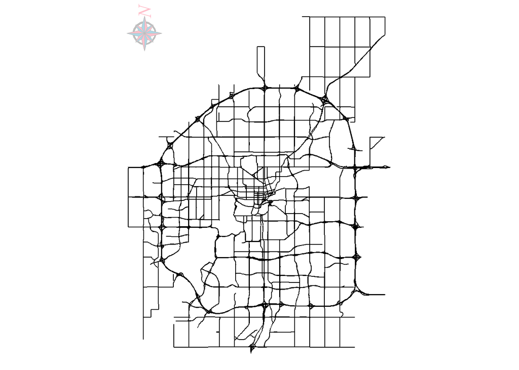

```r
edmonton_map +
  annotation_north_arrow(location = "tl",
                         style = north_arrow_nautical(line_width = 2,
                                                     line_col = "gray",
                                                     fill = c("lightblue", "pink"),
                                                     text_size = 18,
                                                     text_face = "italic",
                                                     text_family = "serif",
                                                     text_col = "pink",
                                                     text_angle = 90))
```